# Effects of truncation distance on estimated perceptibility of Streaked Horned Larks

Author

John D. Lloyd

Published

May 1, 2023

# Estimating perceptibility of singing larks with distance sampling

During the 2022 field season, observers recorded the distance to any Streaked Horned Larks that were detected. Distances were grouped into 4 bands: 0-25 m, 26-100 m, 101 - 200 m, and > 200 m. To generate an estimate of detectability and abundance, we have to assign an outermost distance beyond which we do not expect any detections to occur. In initial analyses, we used 400 m as the putative outer boundary as we did not expect observers to detect larks beyond this distance. The choice of an outermost distance should reflect the biology of the species, but the choice will also influence estimates of detectability and abundance. In general, estimates of detectability and abundance will decline as the outer boundary increases.

Estimated detectability was surprisingly low based on initial analyses. One explanation was that our outer distance boundary was too far. To test this idea, I repeated the distance-sampling analyses with an assumed outermost detection distance of 300 m. I ran the same subset of models and used the same model-selection procedure to determine the best model. As expected, the ranking of models did not change, and the model that included a negative effect of day-of-the-year was ranked highest for both analyses.

## Estimated perceptibility is only modestly higher when truncation distance is shortened to 300 m

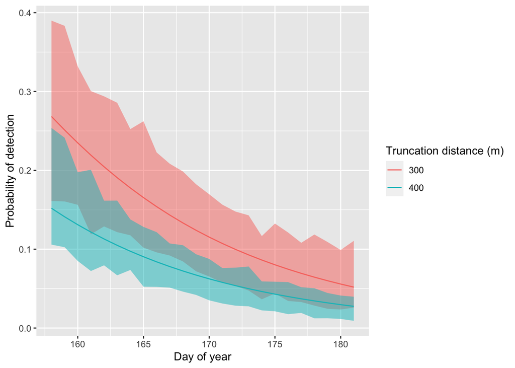

Figure 1: Perceptibility of larks as a function of whether truncation distance is 300 m or 400 m.

Estimated detectability was somewhat higher when I used 300 m as the outermost distance at which observers could detect a lark (Figure 1). However, detectability was still lower than expected. On the median day of the season, the estimated probability of detecting a singing lark was 0.11 when I assumed an outer boundary of 300 m and was 0.06 when I assumed an outer boundary of 400 m. Thus, even though detectability estimates increased when we shortened the truncation distance, the best model still estimates that observers detect a small fraction of the birds available for detection during surveys.

## Reducing truncation distance without a empirical basis for doing so can bias estimates of perceptibility

We do not know the actual furthest distance at which larks were detected in 2022; observers simply noted if they were more than 200 m away. As such, we have no basis for excluding any detections as we shrink the truncation distance, as in this analysis. That means that all detections in the outermost distance band are simply compressed into a narrower distance band, which in turn means that estimated pereceptibility must increase. The significance of this analysis is thus limited: it simply demonstrates that, all things being equal, reducing truncation distance without any corresponding change in detections increases estimated perceptibility. Importantly, this is not a biological phenomenon.

# Lark distribution as a function of predicted habitat suitability

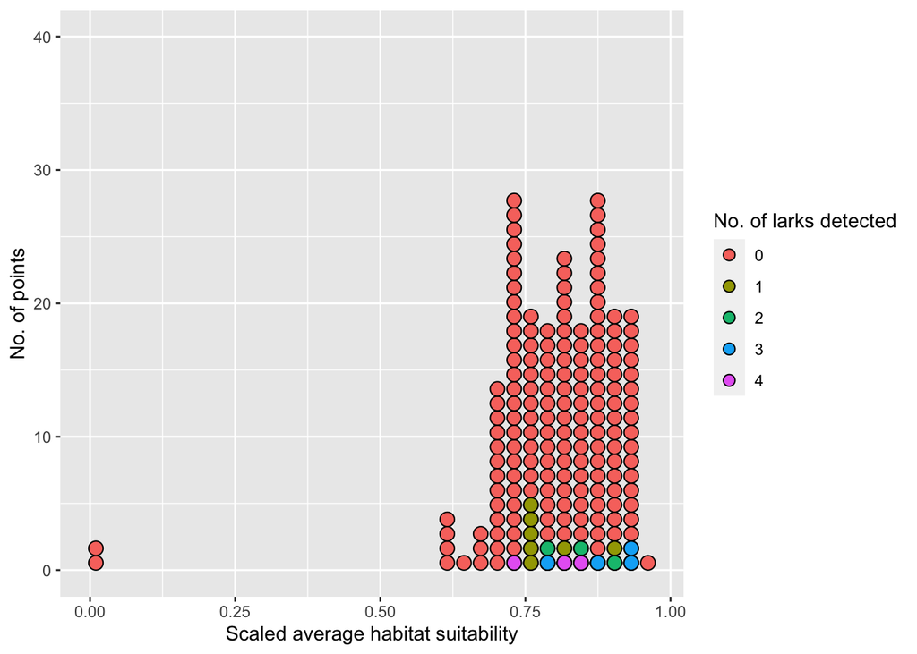

Figure 2: Number of lark detections as a function of average predicted habitat quality at each point surveyed in 2022.

Habitat suitability at each point was predicted for 2017, 2018, 2020, and 2021. To explore the relationship between abundance of larks and predicted habitat suitablity, I plotted lark detections agasint the average maximum habitat suitability score across all yeaars at each point (Figure 2).